# Dissertation Pilot 1

## Assessing effort demand across different likelihoods of switching tasks.

The purpose of this document is to anaylze the first pilot for my dissertation, the data for which was collected in the Fall of 2018.

With this document, I’m investigating both total run time and average trial RT as a function of probability of task switch. The prediction is that both of these outcomes will increase as a function of p(switch). However, it’s possible that, as the likelihood of switching approaches certain (i.e., 1), responding actually becomes *easier*, and outcomes will decrease.

A table with only the first 10,000 of 20253 rows of the data.

```r
datatable(df[1:10000,], filter = 'top', options = list(pageLength = 5, autoWidth = TRUE))
```

|  | subject | procedure | pSwitch | stim | trial | taskcode | transition | rt | error | errortrim |
| --- | --- | --- | --- | --- | --- | --- | --- | --- | --- | --- |
| 1 | 2 | cuedproc | 0.2 | 8 | 2 | mag | Rep | 754 | 0 | 0 |
| 2 | 2 | cuedproc | 0.2 | 3 | 3 | mag | Rep | 722 | 0 | 0 |
| 3 | 2 | cuedproc | 0.2 | 1 | 4 | mag | Rep | 635 | 0 | 0 |
| 4 | 2 | cuedproc | 0.2 | 2 | 5 | mag | Rep | 681 | 0 | 0 |
| 5 | 2 | cuedproc | 0.2 | 7 | 6 | mag | Rep | 620 | 0 | 0 |
| 6 | 2 | cuedproc | 0.2 | 3 | 7 | mag | Rep | 738 | 0 | 0 |
| 7 | 2 | cuedproc | 0.2 | 9 | 8 | mag | Rep | 691 | 0 | 0 |
| 8 | 2 | cuedproc | 0.2 | 6 | 9 | mag | Rep | 782 | 0 | 0 |
| 9 | 2 | cuedproc | 0.2 | 4 | 10 | mag | Rep | 821 | 0 | 0 |
| 10 | 2 | cuedproc | 0.2 | 7 | 11 | mag | Rep | 770 | 0 | 0 |

[output cut: 9990 more lines]

Sample size is:

```r
df %>%
  group_by(subject) %>%
  summarize(n()) %>%
  nrow()
```

```
## [1] 17
```

A quick look at the RT and error distribution:

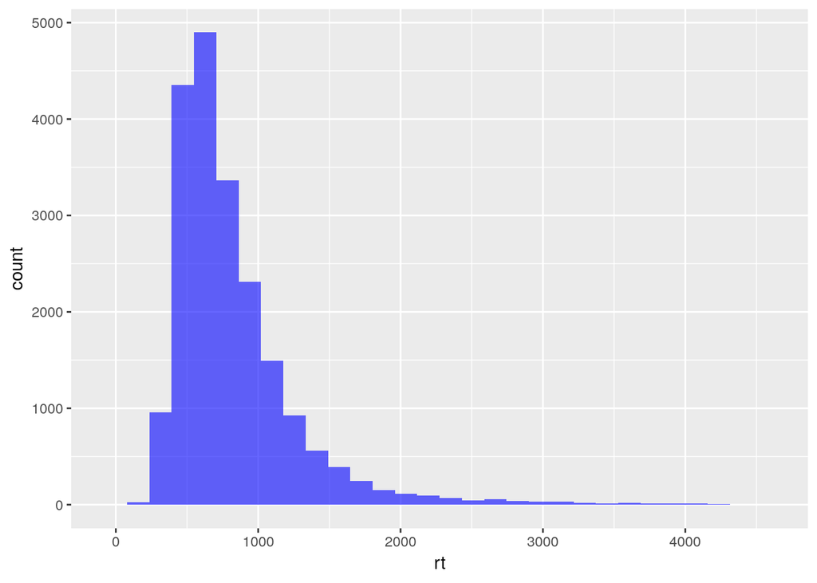

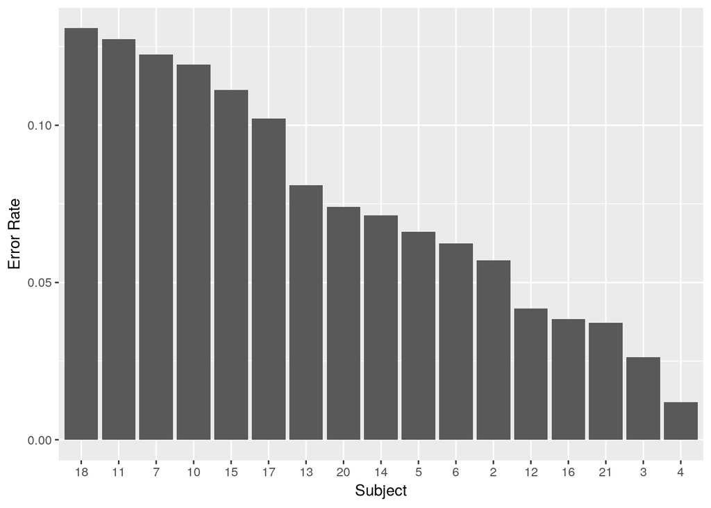

### Total run time

This will really just be summing all rts within a run by participants and then averaging across participants.

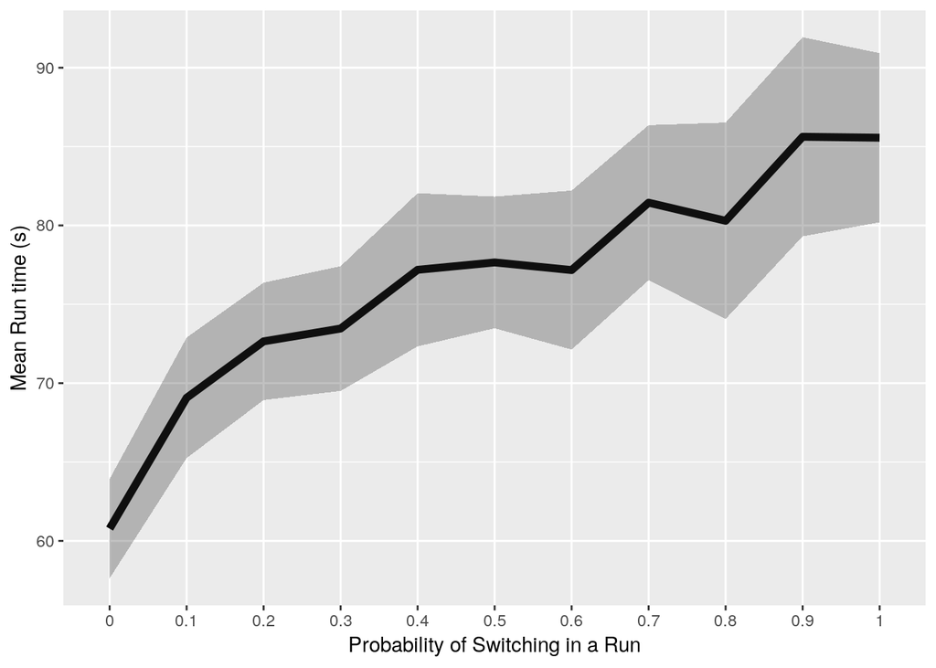

Looks pretty monotonic to me. Next up is average RT per trial.

### Average RT

Calculating the average RT per p(switch) per participant and then averaging across participants.

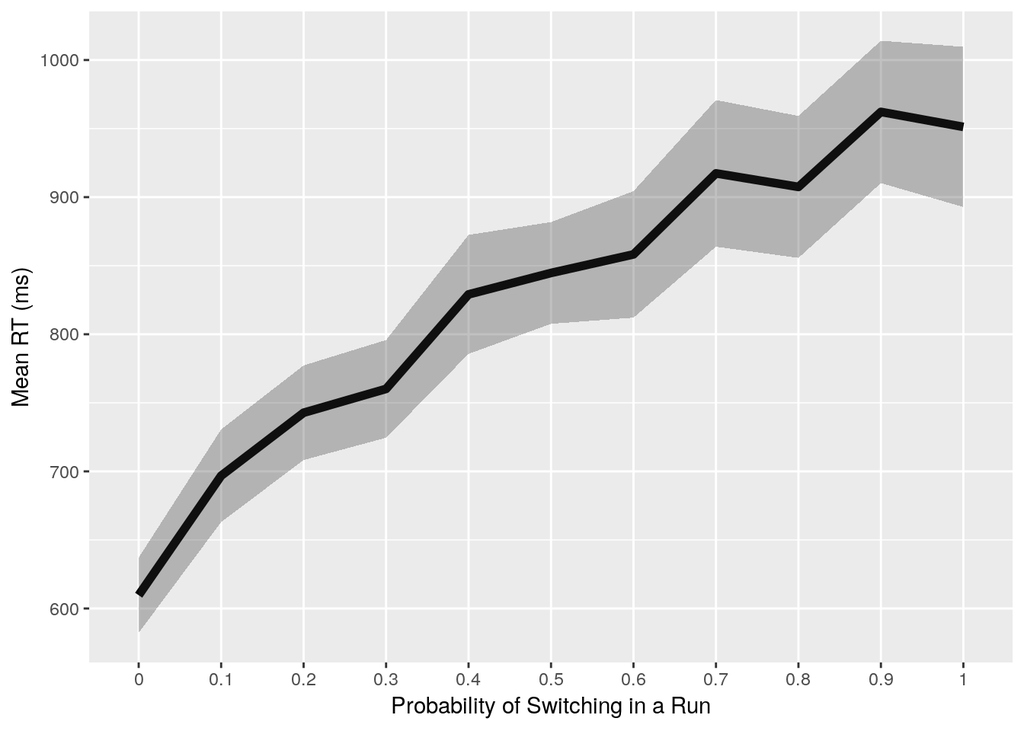

Now I’m doing the same but for errors

## Error Rates

### Total errors across a run

Summing errors within a run by participant and then averaging across participants

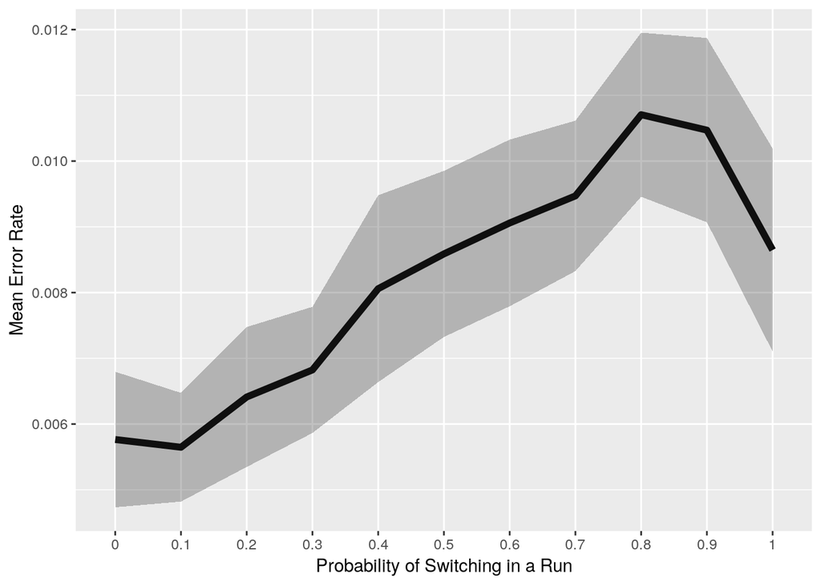

```r
df %>%
  group_by(subject, pSwitch) %>%
  summarize(eRate = sum(error)) %>%
  group_by(pSwitch) %>%
  summarize(errorRate = mean(eRate) / 1000, se = (sd(eRate) / sqrt(n())) / 1000) %>%
  ggplot(aes(x = as.factor(pSwitch), y = errorRate, group = 1)) + geom_line(size = 2) + xlab('Probability of Switching in a Run') + ylab('Mean Error Rate') + geom_ribbon(aes(ymin = errorRate - se, ymax = errorRate + se), alpha = .3)
```

Interesting, this tells a slightly different story from the RTs.. at least with respect to the difference between 0.9 and 1.

### Average errors per run

Taking the average number of errors per participant per switch condition and then averaging across participants

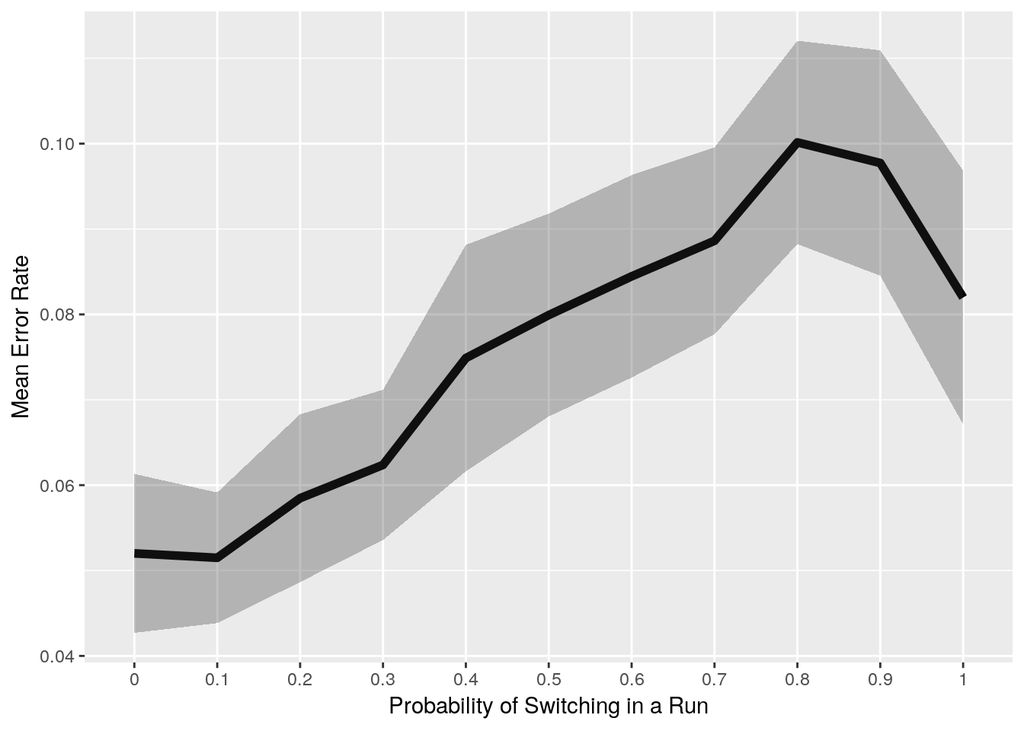

```r
df %>%
  group_by(subject, pSwitch) %>%
  summarize(eRate = mean(error)) %>%
  group_by(pSwitch) %>%
  summarize(errorRate = mean(eRate), se = sd(eRate) / sqrt(n())) %>%
  ggplot(aes(x = factor(pSwitch), y = errorRate, group = 1)) + geom_line(size = 2) + xlab('Probability of Switching in a Run') + ylab('Mean Error Rate') + geom_ribbon(aes(ymin = errorRate - se, ymax = errorRate + se), alpha = .3)
```

Pretty much the same idea as total number of errors per run.

Let’s put an RT graph together with an error graph to use as a figure for the document.

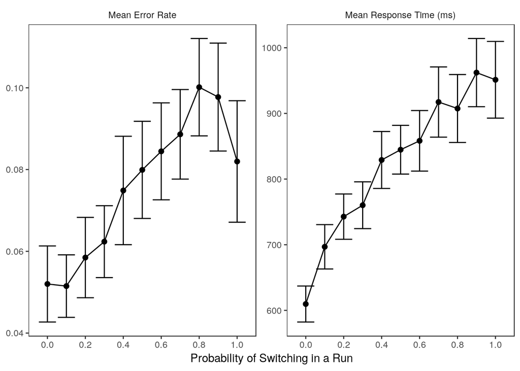

```r
graphData <- df %>%
  filter(errortrim == 0) %>%
  group_by(subject, pSwitch) %>%
  summarize(rt = mean(rt)) %>%
  group_by(pSwitch) %>%
  summarize(rTime = mean(rt), se = sd(rt) / sqrt(n()))

graphData <- df %>%
  group_by(subject, pSwitch) %>%
  summarize(eRate = mean(error)) %>%
  group_by(pSwitch) %>%
  summarize(errorRate = mean(eRate), se = sd(eRate) / sqrt(n())) %>%
  inner_join(graphData, by = 'pSwitch') %>%
  gather(variable, value, errorRate, rTime) %>%
  mutate(se = ifelse(variable == 'errorRate', se.x, se.y)) %>%
  select(-se.x, -se.y)

graphData$variable <- factor(graphData$variable)
levels(graphData$variable) <- c('Mean Error Rate', 'Mean Response Time (ms)')


ggplot(graphData, aes(x = pSwitch, y = value, group = 1)) + geom_line() + geom_point(size = 2) +
  geom_errorbar(aes(ymax = value + se, ymin = value - se)) +
  #geom_ribbon(aes(ymax = value + se, ymin = value - se), alpha = .2) +
  facet_wrap(~variable, scales = 'free') +
  xlab('Probability of Switching in a Run') + theme_bw() +
  scale_x_continuous(breaks = seq(0,1,0.2)) +
  theme(panel.grid.major = element_blank(), panel.grid.minor = element_blank(),
        strip.background = element_blank(),
        axis.title.y = element_blank())
```

```r
ggsave('pilotSummary.png', height = 3.5, width = 5.5, units = 'in')
```